# GLM_ClaimInd

### Visualisation des résidus

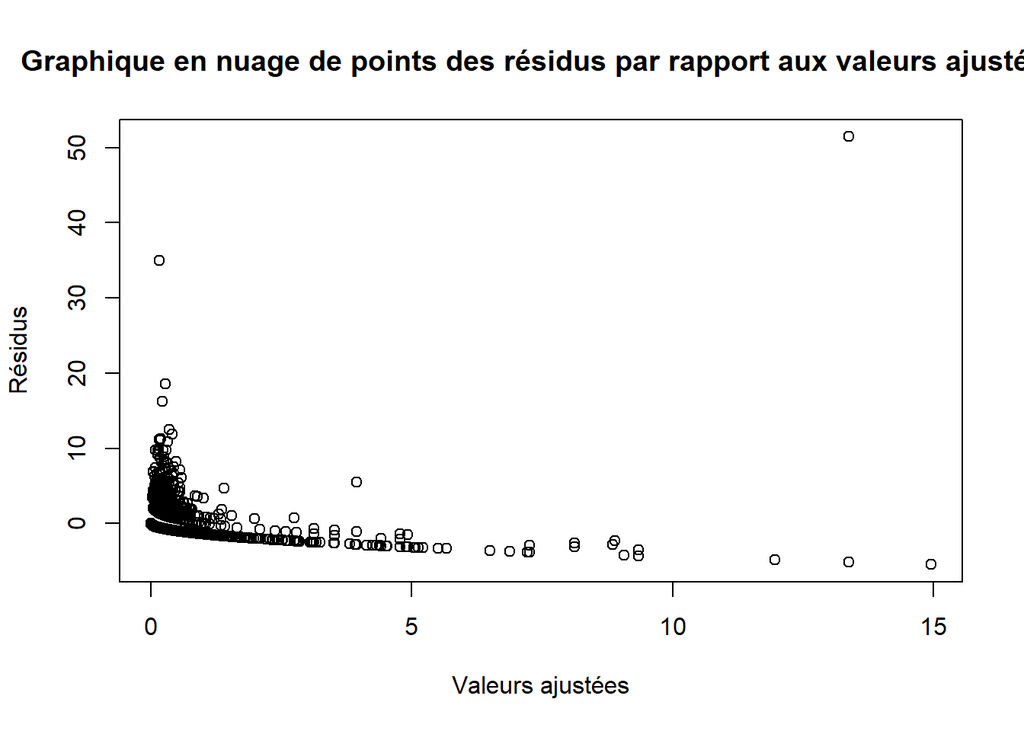

```r
plot(mod_final$fitted.values, residus, xlab = "Valeurs ajustées", ylab="Résidus", main = "Graphique en nuage de points des résidus par rapport aux valeurs ajustées")
```

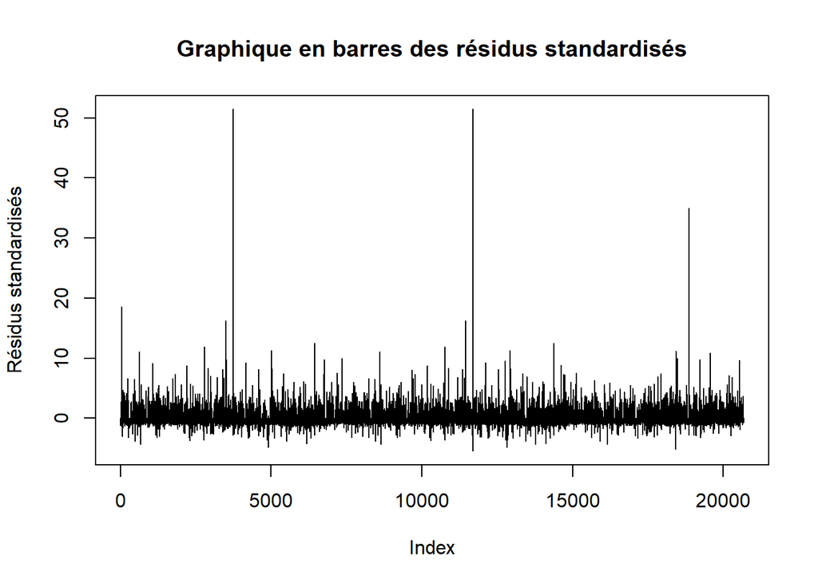

```r
plot(residus, type="h", ylab="Résidus standardisés", main = "Graphique en barres des résidus standardisés")
```

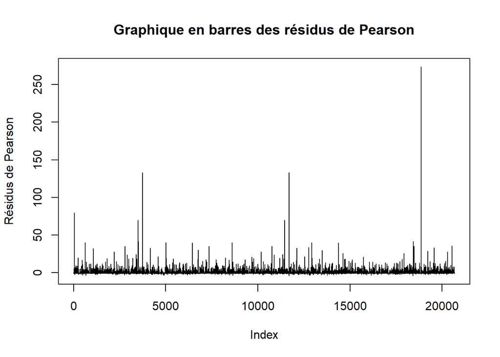

```r
plot(resid(mod_final, type = "pearson"),type = "h", ylab="Résidus de Pearson", main="Graphique en barres des résidus de Pearson")
```

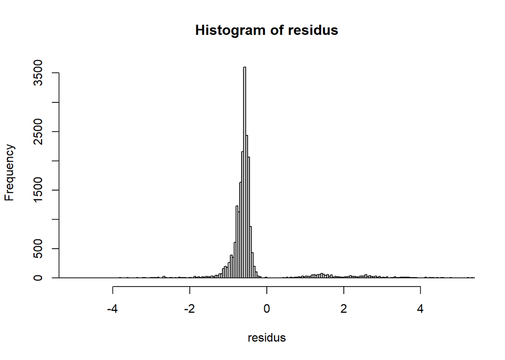

```r
hist(residus, nclass=1000, xlim=c(-5,5))
```

Avec l’histogramme des résidus, on peut bien voir que le modèle a tendance à surévaluer le nombre de sinistres car les valeurs importantes de l’échantillon de données biaisent la prédiction.

## d) Etude des outliers

Calculons dans un premier temps les résidus de Pearson

```r
inf <- influence.measures(mod_final)
pearson_resid <- inf$infmat
```

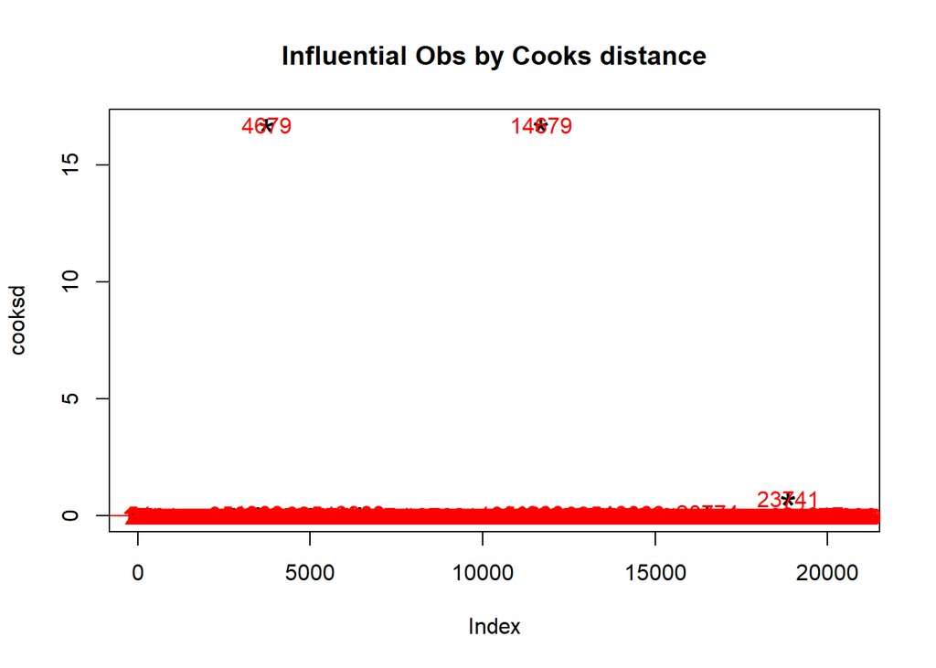

```r
cooksd <- cooks.distance(modBoth_2)

sample_size <- nrow(train)
plot(cooksd, pch="*", cex=2, main="Influential Obs by Cooks distance")  # plot cook's distance
abline(h = 4/sample_size, col="red")  # add cutoff line
text(x=1:length(cooksd)+1, y=cooksd, labels=ifelse(cooksd>4/sample_size, names(cooksd),""), col="red")  # add labels
```

Voici un moyen classque de trouver et retirer les outliers.

```r
outliers=as.numeric(names(cooksd)[(cooksd > (4/length(train)))])

fin=length(outliers) #On pourrait ici modifier pour changer le nombre d'outliers à retirer du data d'entrainement.
(fin)
```

```
## [1] 3
```

```r
outliers=as.numeric(names(sort(cooksd, decreasing = TRUE)[1:fin]))

train_sansoutliers <- train[-c(outliers), ]

modFull_Outliers <- glm(Sinistres2 ~ ClaimNbResp+ClaimNbNonResp+ClaimNbParking+ClaimNbFireTheft+ClaimNbWindscreen+OutUseNb+BonusMalus+DrivAge_fact+Categ+Risque*MariStat+HasKmLimit+VehUsage+Categ:MariStat+Categ:DrivAge_fact, data = train_sansoutliers, family = poisson(link = "log"))
summary(modFull_Outliers)
```

```
##
## Call:
## glm(formula = Sinistres2 ~ ClaimNbResp + ClaimNbNonResp + ClaimNbParking +
##     ClaimNbFireTheft + ClaimNbWindscreen + OutUseNb + BonusMalus +
##     DrivAge_fact + Categ + Risque * MariStat + HasKmLimit + VehUsage +
##     Categ:MariStat + Categ:DrivAge_fact, family = poisson(link = "log"),
##     data = train_sansoutliers)
##
## Deviance Residuals:
##    Min      1Q  Median      3Q     Max
## -5.467  -0.703  -0.575  -0.493  51.458
##
## Coefficients: (4 not defined because of singularities)
##                                  Estimate Std. Error z value Pr(>|z|)
## (Intercept)                    -3.095e+00  4.645e-01  -6.662 2.70e-11 ***
## ClaimNbResp                    -1.152e-01  2.827e-02  -4.074 4.62e-05 ***
## ClaimNbNonResp                  6.099e-01  1.498e-02  40.724  < 2e-16 ***
## ClaimNbParking                 -4.917e-02  4.385e-02  -1.121 0.262139
## ClaimNbFireTheft               -3.078e-01  5.033e-02  -6.117 9.56e-10 ***
## ClaimNbWindscreen               1.107e-01  1.700e-02   6.512 7.41e-11 ***
## OutUseNb                        9.691e-03  1.793e-02   0.540 0.588935
## BonusMalus                     -3.507e-04  1.300e-03  -0.270 0.787249
## DrivAge_fact(25,30]             6.739e-01  4.450e-01   1.514 0.129907
## DrivAge_fact(30,35]            -7.395e-01  5.778e-01  -1.280 0.200588
## DrivAge_fact(35,40]             1.288e+00  4.355e-01   2.958 0.003092 **
## DrivAge_fact(40,45]            -4.802e-01  4.940e-01  -0.972 0.331038
## DrivAge_fact(45,50]             5.229e-01  4.456e-01   1.174 0.240594
## DrivAge_fact(50,58]            -3.360e-01  4.489e-01  -0.749 0.454092
## DrivAge_fact(58,65]             4.296e-01  4.655e-01   0.923 0.356055
## DrivAge_fact(65,120]           -9.151e-01  6.507e-01  -1.406 0.159609
## Categ1                          2.513e+00  6.115e-01   4.110 3.96e-05 ***
## Categ2                         -1.051e+01  2.847e+02  -0.037 0.970543
## Categ3                          1.663e+00  3.521e-01   4.723 2.33e-06 ***
## Categ4                          1.274e+00  6.458e-01   1.972 0.048590 *
## Risque1                         1.194e-01  2.843e-01   0.420 0.674599
## Risque2                         5.493e-01  2.887e-01   1.903 0.057062 .
## Risque3                         3.705e-01  2.992e-01   1.238 0.215609
## Risque4                        -3.661e-01  4.563e-01  -0.802 0.422384
## MariStatOther                   1.105e+00  4.387e-01   2.518 0.011798 *
## HasKmLimit1                    -8.867e-02  6.531e-02  -1.358 0.174545
```

[output cut: 38 more lines]

```
## DrivAge_fact(40,45]:Categ4     -1.059e+01  2.013e+02  -0.053 0.958044
## DrivAge_fact(45,50]:Categ4     -1.272e+01  2.847e+02  -0.045 0.964366
## DrivAge_fact(50,58]:Categ4     -1.145e+00  5.863e-01  -1.953 0.050789 .
## DrivAge_fact(58,65]:Categ4     -1.501e+00  5.486e-01  -2.735 0.006237 **
## DrivAge_fact(65,120]:Categ4            NA         NA      NA       NA
## ---
## Signif. codes:  0 '***' 0.001 '**' 0.01 '*' 0.05 '.' 0.1 ' ' 1
##
## (Dispersion parameter for poisson family taken to be 1)
##
##     Null deviance: 39128  on 20677  degrees of freedom
## Residual deviance: 32904  on 20613  degrees of freedom
## AIC: 37986
##
## Number of Fisher Scoring iterations: 10
```

```r
summary(mod_inter)
```

```
##
## Call:
## glm(formula = Sinistres2 ~ ClaimNbResp + ClaimNbNonResp + ClaimNbParking +
##     ClaimNbFireTheft + ClaimNbWindscreen + OutUseNb + BonusMalus +
##     DrivAge_fact + Categ + Risque * MariStat + HasKmLimit + VehUsage +
##     Categ:MariStat + Categ:DrivAge_fact, family = poisson(link = "log"),
##     data = train)
##
## Deviance Residuals:
##    Min      1Q  Median      3Q     Max
## -5.467  -0.703  -0.575  -0.493  51.457
##
## Coefficients: (4 not defined because of singularities)
##                                  Estimate Std. Error z value Pr(>|z|)
## (Intercept)                     -3.094749   0.464520  -6.662 2.70e-11 ***
## ClaimNbResp                     -0.115241   0.028273  -4.076 4.58e-05 ***
## ClaimNbNonResp                   0.609915   0.014976  40.727  < 2e-16 ***
## ClaimNbParking                  -0.049142   0.043849  -1.121 0.262403
## ClaimNbFireTheft                -0.308206   0.050332  -6.124 9.15e-10 ***
## ClaimNbWindscreen                0.110732   0.017001   6.513 7.35e-11 ***
## OutUseNb                         0.009699   0.017933   0.541 0.588613
## BonusMalus                      -0.000349   0.001300  -0.269 0.788249
## DrivAge_fact(25,30]              0.673844   0.444948   1.514 0.129916
## DrivAge_fact(30,35]             -0.739523   0.577784  -1.280 0.200570
## DrivAge_fact(35,40]              1.288326   0.435462   2.959 0.003091 **
## DrivAge_fact(40,45]             -0.480167   0.494028  -0.972 0.331079
## DrivAge_fact(45,50]              0.522984   0.445605   1.174 0.240535
## DrivAge_fact(50,58]             -0.335967   0.448872  -0.748 0.454176
## DrivAge_fact(58,65]              0.429658   0.465460   0.923 0.355964
## DrivAge_fact(65,120]            -0.915121   0.650702  -1.406 0.159617
## Categ1                           2.512841   0.611456   4.110 3.96e-05 ***
## Categ2                         -10.511518 284.659392  -0.037 0.970543
## Categ3                           1.662670   0.352077   4.722 2.33e-06 ***
## Categ4                           1.273839   0.645812   1.972 0.048557 *
## Risque1                          0.119358   0.284303   0.420 0.674612
## Risque2                          0.549287   0.288669   1.903 0.057063 .
## Risque3                          0.370461   0.299175   1.238 0.215614
## Risque4                         -0.366087   0.456282  -0.802 0.422364
## MariStatOther                    1.104869   0.438716   2.518 0.011788 *
## HasKmLimit1                     -0.088634   0.065306  -1.357 0.174715
```

[output cut: 38 more lines]

```
## DrivAge_fact(40,45]:Categ4     -10.588848 201.285250  -0.053 0.958046
## DrivAge_fact(45,50]:Categ4     -12.717483 284.659669  -0.045 0.964365
## DrivAge_fact(50,58]:Categ4      -1.145218   0.586289  -1.953 0.050780 .
## DrivAge_fact(58,65]:Categ4      -1.501077   0.548643  -2.736 0.006219 **
## DrivAge_fact(65,120]:Categ4            NA         NA      NA       NA
## ---
## Signif. codes:  0 '***' 0.001 '**' 0.01 '*' 0.05 '.' 0.1 ' ' 1
##
## (Dispersion parameter for poisson family taken to be 1)
##
##     Null deviance: 39129  on 20679  degrees of freedom
## Residual deviance: 32905  on 20615  degrees of freedom
## AIC: 37987
##
## Number of Fisher Scoring iterations: 10
```

On ne gagne pas beaucoup en AIC en retirant les outliers donc nous allons les garder.

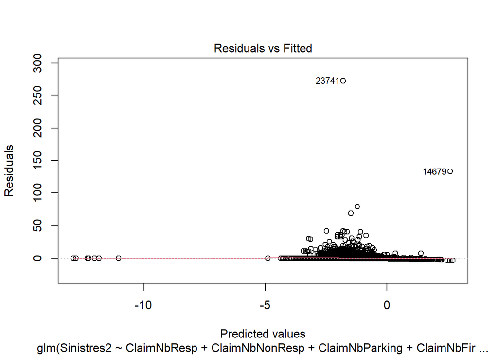

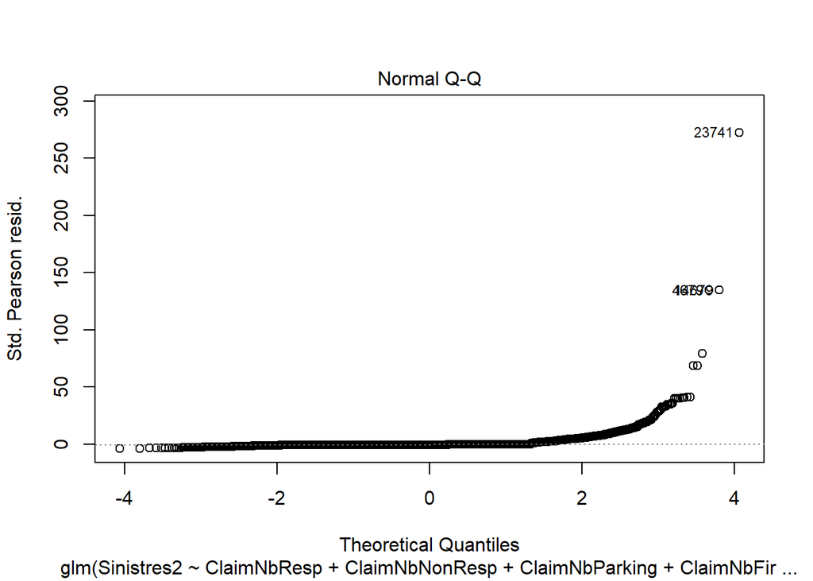

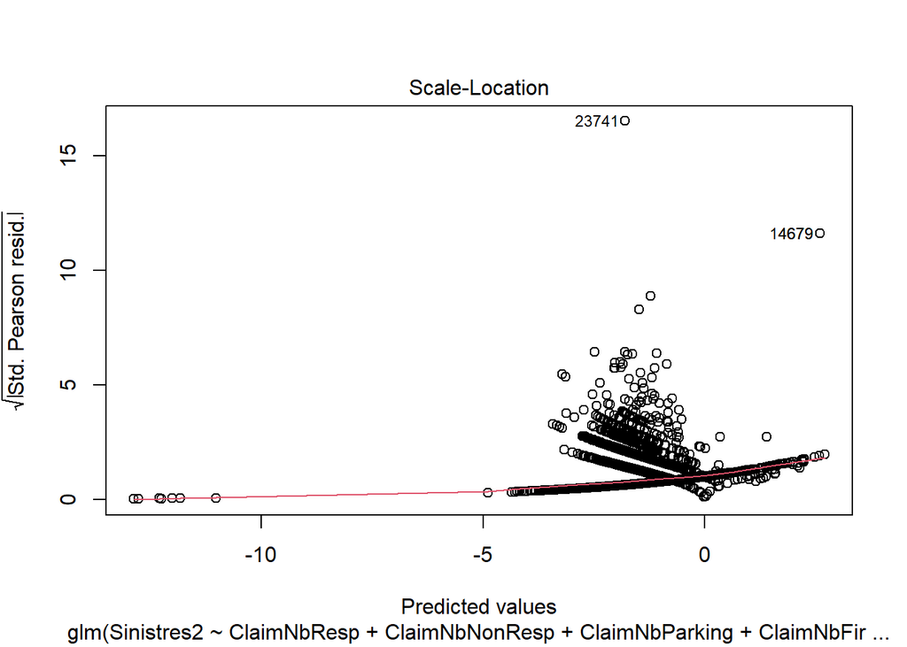

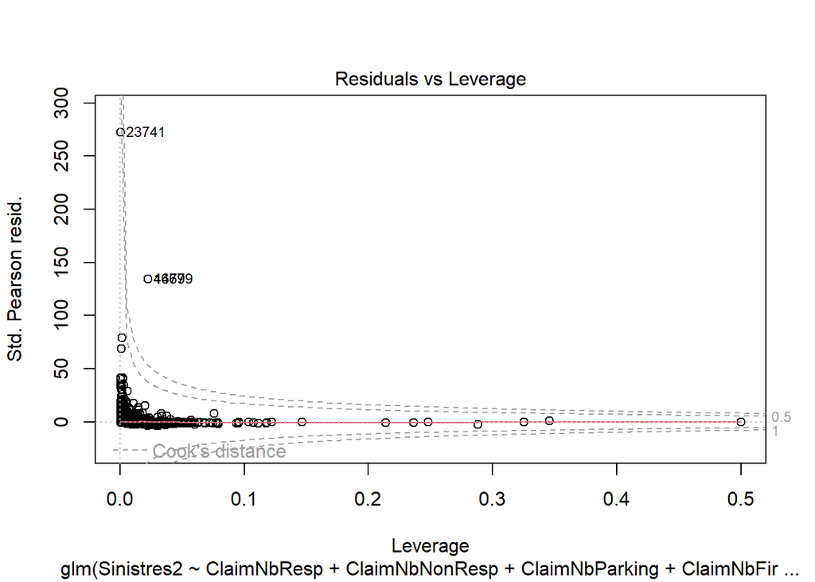

```r
plot(modFull_Outliers)
```

## e) Qualité de prédiction

### Evaluation du modèle sur les données tests

```r
estimation <- mod_final$fitted.values
hist(estimation)
```

[output not shown]

### Utilisation de métriques de comparaison

#### RMSE

```r
RMSE_train <- sqrt(mean(mod_final$residuals^2))
RMSE_train
```

```
## [1] 7.328725
```

### Table de confusion

#### Sur le jeu de données train

```r
estimation <- mod_final$fitted.values
hist(estimation)
```

[output not shown]

```r
score <- round(predict(mod_final,train,type="response"))
confusion.mat = table(train$Sinistres2, score)

confusion.mat
```

```
##      score
##           0     1     2     3     4     5     6     7     8     9    12    13
##   0   17534   914   102    44    67    25    17     9     0     8     2     1
##   1     778    47     5     5     7     2     0     2     2     1     0     0
##   2     600    55     0     1     3     2     0     0     2     1     0     0
##   3     159    15     3     0     0     0     0     0     0     1     0     0
##   4      91    10     0     2     0     0     0     0     0     0     0     0
##   5      31     2     0     0     0     0     0     0     0     0     0     0
##   6      34     8     0     0     0     0     0     0     0     0     0     0
##   7      13     2     0     0     0     0     0     0     0     0     0     0
##   8      14     1     0     0     0     0     0     0     0     0     0     0
##   9       2     0     0     0     0     0     0     0     0     0     0     0
##   10      5     3     0     0     0     0     0     0     0     0     0     0
##   11      6     0     0     0     0     0     0     0     0     0     0     0
##   12     13     1     0     0     0     0     0     0     0     0     0     0
```

[output cut: 41 more lines]

#### Sur le jeu de données test

```r
estimation <- mod_final$fitted.values
hist(estimation)
```

[output not shown]

```r
score <- round(predict(mod_final,test,type="response"))
confusion.mat = table(test$Sinistres2, score)

confusion.mat
```

```
##     score
##         0    1    2    3    4    5    9   13   15
##   0  4273  242   29   10   21    2    1    1    1
##   1   174   14    0    1    1    0    0    0    0
##   2   139   12    0    1    1    1    0    0    0
##   3    33    7    0    0    0    0    0    0    0
##   4    35    2    1    0    0    0    0    0    0
##   5     9    0    0    0    0    0    0    0    0
##   6     8    2    0    0    0    0    0    0    0
##   7     4    0    0    0    0    0    0    0    0
##   8     3    0    0    0    0    0    0    0    0
##   9     2    0    0    0    0    0    0    0    0
##   10    1    1    0    0    0    0    0    0    0
##   12    3    0    0    0    0    0    0    0    0
##   13    2    0    0    0    0    0    0    0    0
##   14    1    0    0    0    0    0    0    0    0
##   15    1    0    0    0    0    0    0    0    0
##   32    1    0    0    0    0    0    0    0    0
##   43    1    0    0    0    0    0    0    0    0
##   48    1    0    0    0    0    0    0    0    0
```

# Conclusion

Le `mod_final` prédit plutôt bien les individus qui n’ont pas d’accidents (tout comme le modèle binomial) car ces individus représentent une grosse partie de l’échantillon. Cependant, pour les individus ayant eu des sinistres, l’estimation est plus difficile. Cependant, faute de pouvoir faire mieux avec les données dont nous disposons, c’est le modèle que nous garderons.

Pour rappel, voici le modèle :

```r
summary(mod_final)
```

```
##
## Call:
## glm(formula = Sinistres2 ~ ClaimNbResp + ClaimNbNonResp + ClaimNbFireTheft +
##     ClaimNbWindscreen + DrivAge_fact + Categ + Risque + MariStat +
##     VehUsage + Risque:MariStat + Categ:MariStat + DrivAge_fact:Categ,
##     family = poisson(link = "log"), data = train)
##
## Deviance Residuals:
##    Min      1Q  Median      3Q     Max
## -5.469  -0.701  -0.573  -0.491  51.458
##
## Coefficients: (4 not defined because of singularities)
##                                 Estimate Std. Error z value Pr(>|z|)
## (Intercept)                     -3.12922    0.44630  -7.011 2.36e-12 ***
## ClaimNbResp                     -0.11805    0.02600  -4.540 5.64e-06 ***
## ClaimNbNonResp                   0.61108    0.01494  40.892  < 2e-16 ***
## ClaimNbFireTheft                -0.30709    0.05031  -6.104 1.03e-09 ***
## ClaimNbWindscreen                0.11144    0.01695   6.576 4.84e-11 ***
## DrivAge_fact(25,30]              0.67555    0.44463   1.519 0.128678
## DrivAge_fact(30,35]             -0.73179    0.57726  -1.268 0.204904
## DrivAge_fact(35,40]              1.29609    0.43374   2.988 0.002807 **
## DrivAge_fact(40,45]             -0.46939    0.49164  -0.955 0.339708
## DrivAge_fact(45,50]              0.53525    0.44295   1.208 0.226905
## DrivAge_fact(50,58]             -0.32573    0.44648  -0.730 0.465666
## DrivAge_fact(58,65]              0.44530    0.46289   0.962 0.336042
## DrivAge_fact(65,120]            -0.91025    0.64896  -1.403 0.160728
## Categ1                           2.51563    0.61115   4.116 3.85e-05 ***
## Categ2                         -10.50508  284.65936  -0.037 0.970562
## Categ3                           1.65917    0.35197   4.714 2.43e-06 ***
## Categ4                           1.26397    0.64583   1.957 0.050332 .
## Risque1                          0.11952    0.28401   0.421 0.673885
## Risque2                          0.54810    0.28836   1.901 0.057332 .
## Risque3                          0.36160    0.29887   1.210 0.226327
## Risque4                         -0.35691    0.45596  -0.783 0.433767
## MariStatOther                    1.10516    0.43864   2.520 0.011752 *
## VehUsagePrivate+trip to office   0.05505    0.05059   1.088 0.276578
## VehUsageProfessional             0.36135    0.05731   6.305 2.88e-10 ***
## VehUsageProfessional run        -0.46868    0.09015  -5.199 2.00e-07 ***
## Risque1:MariStatOther           -0.28281    0.29505  -0.959 0.337799
## Risque2:MariStatOther           -0.95852    0.30084  -3.186 0.001442 **
```

[output cut: 33 more lines]

```
## DrivAge_fact(40,45]:Categ4     -10.56680  201.28525  -0.052 0.958133
## DrivAge_fact(45,50]:Categ4     -12.69316  284.65967  -0.045 0.964434
## DrivAge_fact(50,58]:Categ4      -1.13685    0.58622  -1.939 0.052467 .
## DrivAge_fact(58,65]:Categ4      -1.50578    0.54860  -2.745 0.006056 **
## DrivAge_fact(65,120]:Categ4           NA         NA      NA       NA
## ---
## Signif. codes:  0 '***' 0.001 '**' 0.01 '*' 0.05 '.' 0.1 ' ' 1
##
## (Dispersion parameter for poisson family taken to be 1)
##
##     Null deviance: 39129  on 20679  degrees of freedom
## Residual deviance: 32908  on 20619  degrees of freedom
## AIC: 37982
##
## Number of Fisher Scoring iterations: 10
```